# Covid

#Load data and packages

```r
suppressPackageStartupMessages(lapply(c('plyr','ggfortify', 'viridis', 'ggplot2','RColorBrewer', 'reshape2', 'phyloseq', 'vegan', 'cowplot', 'dplyr', 'gplots', 'hillR', 'betapart',  'tidyverse', 'Carrotworks', 'Maaslin2', 'brmstools'), require,character.only=TRUE)) #add as necessary
```

[output not shown]

Plot sequencing qualities- code is from Dr. Carrot Herself, files are outputted by Steph’s pipeline Remy: not relevant for you

```r
setwd("/Users/sj40zura/Dropbox/In Progress/Reuben/COVID/round2/")
```

[output not shown]

Plot reads from the dadasnake object Remy: not relevant for you

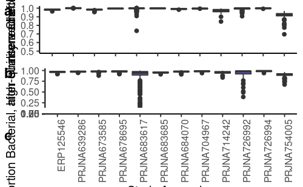

```r
merged_all@sam_data$ratio=merged_all@sam_data$Filtered.Reads/merged_all@sam_data$Original.Reads
merged_all@sam_data$ratio2=merged_all@sam_data$Non.chimeric.Reads/merged_all@sam_data$Original.Reads
merged_all@sam_data$ratio3=merged_all@sam_data$pseq/merged_all@sam_data$Original.Reads


Allreads=ggplot(merged_all@sam_data, aes(x=Study.Accession, y=ratio, group=Study.Accession))+
  geom_boxplot(fill="#9595f9")+
  theme_classic()+
  theme(axis.text.x = element_blank(),axis.title.x=element_blank())+
  ylim(0.5,1)+
  ylab("Reads conserved after Filtering")


Non.chimeric=ggplot(merged_all@sam_data, aes(x=Study.Accession, y=ratio2, group=Study.Accession))+
  geom_boxplot(fill="#5959c6")+
  theme_classic()+
  theme(axis.text.x = element_blank(),axis.title.x=element_blank())+
  ylim(0,1)+
  ylab("Reads conserved after Chimera Checking")


tabled=ggplot(merged_all@sam_data, aes(x=Study.Accession, y=ratio3, group=Study.Accession))+
  geom_boxplot(fill="#333370")+
  ylab("Proportion Bacterial, high-quality reads")+
  ylim(0,1)+
  theme_classic()+
  theme(axis.text.x = element_text(angle = 90, hjust = 1))

cowplot::plot_grid(Allreads, Non.chimeric, tabled, nrow=3, labels=c("a", "b", "c"))
```

#rarefy and plot quality rarefaction results n 1426 samples preserved

```r
rarefied=rarefy_even_depth(merged_all, rngseed = 1, sample.size = 2000)
```

```
`set.seed(1)` was used to initialize repeatable random subsampling.
Please record this for your records so others can reproduce.
Try `set.seed(1); .Random.seed` for the full vector
...
68 samples removedbecause they contained fewer reads than `sample.size`.
Up to first five removed samples are:

SRR13067612SRR13219166SRR13219167SRR13219168SRR13219169
...
20455OTUs were removed because they are no longer
present in any sample after random subsampling

...
```

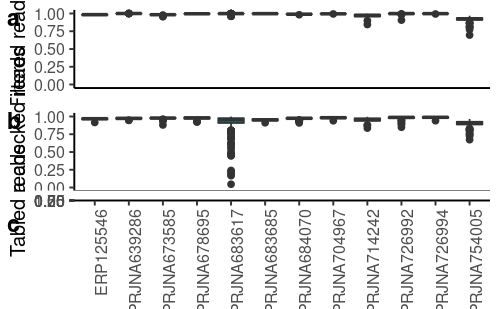

```r
rarefied@sam_data$ID=interaction(rarefied@sam_data$Study.Accession, rarefied@sam_data$Region)

saveRDS(rarefied, "rarefied.rds")


filtered=ggplot(rarefied@sam_data, aes(x=Study.Accession, y=Filtered.Reads/Original.Reads, group=Study.Accession))+
   geom_boxplot(fill="deepskyblue4")+
   theme_classic()+
   theme(axis.text.x = element_text(angle = 90, hjust = 1),axis.title.x=element_blank())+
   ylim(0,1)+
   ylab("Filtered reads")+
   theme(axis.title.x=element_blank(),
        axis.text.x=element_blank(),
        axis.ticks.x=element_blank())
ggsave("Reads conserved after Filtering.jpeg")
checked=ggplot(rarefied@sam_data, aes(x=Study.Accession, y=Non.chimeric.Reads/Original.Reads, group=Study.Accession))+
   geom_boxplot(fill="deepskyblue3")+
   theme_classic()+
   theme(axis.text.x = element_text(angle = 90, hjust = 1),axis.title.x=element_blank())+
   ylim(0,1)+
   ylab("Chimera checked reads")+
   theme(axis.title.x=element_blank(),
        axis.text.x=element_blank(),
        axis.ticks.x=element_blank())
ggsave("Reads conserved after Chimera check.jpeg")
tabled=ggplot(rarefied@sam_data, aes(x=Study.Accession, y=pseq/Original.Reads, group=Study.Accession))+
   geom_boxplot(fill="deepskyblue2")+
   theme_classic()+
   theme(axis.text.x = element_text(angle = 90, hjust = 1),axis.title.x=element_blank())+
   ylim(0,1)+
   ylab("Tabled reads")
ggsave("reads tabled.jpeg")
cowplot::plot_grid(filtered, checked, tabled, nrow = 3,labels =c("a", "b", "c"))
ggsave("reads tabled.pdf")
```

#Sample map

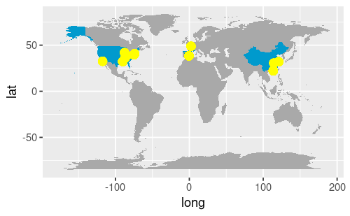

```r
world=map_data("world")

rarefied@sam_data$region=rarefied@sam_data$Country

Counts=as.data.frame(rarefied@sam_data) %>%
    group_by(region) %>%
    tally()

countries=inner_join(world, Counts, by = "region")

Samples=as.data.frame(rarefied@sam_data)

ggplot() +
  geom_polygon(data = world, fill = "darkgray", mapping = aes(x = long, y = lat, group = group))+
  geom_polygon(data = countries, aes(x = long, y = lat, group = group), fill="deepskyblue3")+
  geom_point(data = Samples, aes(x = long, y = lat, color=Sample_type), color="yellow", size=3)
```

#DB RDA

```r
#This function does significance testing on a 3-way variance paritioning. from https://github.com/jgmv/comecol/
test_vp3 <- function(vp, cdm = NULL) {
  # retrieve tables from vp
  y  <- eval(parse(text = vp$call[2]))
  X1 <- as.matrix(eval(parse(text = vp$call[3])))
  X2 <- as.matrix(eval(parse(text = vp$call[4])))
  X3 <- as.matrix(eval(parse(text = vp$call[5])))

  # create an output table
  tab <- rbind(vp$part[[1]][1:4], vp$part[[2]][1:4], vp$part[[3]][1:4])
  tab$percVar <- tab[, "Adj.R.square"] * 100
  tab$P <- rep(NA, nrow(tab))
  #vegan::showvarparts(3)

  if(class(y) == "dist") {
    tab[7, "P"]  <- vegan::anova.cca(vegan::dbrda(y ~ X1 + X2 + X3))$Pr[1]
    tab[1, "P"]  <- vegan::anova.cca(vegan::dbrda(y ~ X1))$Pr[1]
    tab[2, "P"]  <- vegan::anova.cca(vegan::dbrda(y ~ X2))$Pr[1]
    tab[3, "P"]  <- vegan::anova.cca(vegan::dbrda(y ~ X3))$Pr[1]
    tab[4, "P"]  <- vegan::anova.cca(vegan::dbrda(y ~ X1 + X2))$Pr[1]
    tab[5, "P"]  <- vegan::anova.cca(vegan::dbrda(y ~ X1 + X3))$Pr[1]
    tab[6, "P"]  <- vegan::anova.cca(vegan::dbrda(y ~ X2 + X3))$Pr[1]
    tab[8, "P"]  <- vegan::anova.cca(vegan::dbrda(y ~ X1 + Condition(X2) +
      Condition(X3)))$Pr[1]
    tab[9, "P"]  <- vegan::anova.cca(vegan::dbrda(y ~ X2 + Condition(X1) +
      Condition(X3)))$Pr[1]
    tab[10, "P"] <- vegan::anova.cca(vegan::dbrda(y ~ X3 + Condition(X1) +
      Condition(X2)))$Pr[1]
    tab[16, "P"] <- vegan::anova.cca(vegan::dbrda(y ~ X1 + Condition(X3)))$Pr[1]
    tab[17, "P"] <- vegan::anova.cca(vegan::dbrda(y ~ X1 + Condition(X2)))$Pr[1]
    tab[18, "P"] <- vegan::anova.cca(vegan::dbrda(y ~ X2 + Condition(X3)))$Pr[1]
    tab[19, "P"] <- vegan::anova.cca(vegan::dbrda(y ~ X2 + Condition(X1)))$Pr[1]
    tab[20, "P"] <- vegan::anova.cca(vegan::dbrda(y ~ X3 + Condition(X1)))$Pr[1]
    tab[21, "P"] <- vegan::anova.cca(vegan::dbrda(y ~ X3 + Condition(X2)))$Pr[1]
  } else {
    tab[7, "P"]  <- vegan::anova.cca(vegan::rda(y ~ X1 + X2 + X3))$Pr[1]
    tab[1, "P"]  <- vegan::anova.cca(vegan::rda(y ~ X1))$Pr[1]
    tab[2, "P"]  <- vegan::anova.cca(vegan::rda(y ~ X2))$Pr[1]
    tab[3, "P"]  <- vegan::anova.cca(vegan::rda(y ~ X3))$Pr[1]
    tab[4, "P"]  <- vegan::anova.cca(vegan::rda(y ~ X1 + X2))$Pr[1]
    tab[5, "P"]  <- vegan::anova.cca(vegan::rda(y ~ X1 + X3))$Pr[1]
    tab[6, "P"]  <- vegan::anova.cca(vegan::rda(y ~ X2 + X3))$Pr[1]
    tab[8, "P"]  <- vegan::anova.cca(vegan::rda(y ~ X1 + Condition(X2) + Condition(X3)))$Pr[1]
    tab[9, "P"]  <- vegan::anova.cca(vegan::rda(y ~ X2 + Condition(X1) + Condition(X3)))$Pr[1]
    tab[10, "P"] <- vegan::anova.cca(vegan::rda(y ~ X3 + Condition(X1) + Condition(X2)))$Pr[1]
    tab[16, "P"] <- vegan::anova.cca(vegan::rda(y ~ X1 + Condition(X3)))$Pr[1]
    tab[17, "P"] <- vegan::anova.cca(vegan::rda(y ~ X1 + Condition(X2)))$Pr[1]
    tab[18, "P"] <- vegan::anova.cca(vegan::rda(y ~ X2 + Condition(X3)))$Pr[1]
    tab[19, "P"] <- vegan::anova.cca(vegan::rda(y ~ X2 + Condition(X1)))$Pr[1]
    tab[20, "P"] <- vegan::anova.cca(vegan::rda(y ~ X3 + Condition(X1)))$Pr[1]
    tab[21, "P"] <- vegan::anova.cca(vegan::rda(y ~ X3 + Condition(X2)))$Pr[1]
  }
  return(tab)
}


mainvarp <- varpart (vegdist(rarefied@otu_table@.Data), rarefied@sam_data$COVID, rarefied@sam_data$Region, rarefied@sam_data$Study.Accession)

tested=test_vp3(mainvarp)
tested
```

|  | Df | R.square | Adj.R.square | Testable | percVar | P |
| --- | --- | --- | --- | --- | --- | --- |
| [a+d+f+g] = X1 | 2 | 0.02748206 | 0.026115201 | TRUE | 2.6115201 | 0.001 |
| [b+d+e+g] = X2 | 1 | 0.01615388 | 0.015462977 | TRUE | 1.5462977 | 0.001 |
| [c+e+f+g] = X3 | 11 | 0.16283846 | 0.156325887 | TRUE | 15.6325887 | 0.001 |
| [a+b+d+e+f+g] = X1+X2 | 3 | 0.04318886 | 0.041170273 | TRUE | 4.1170273 | 0.001 |
| [a+c+d+e+f+g] = X1+X3 | 13 | 0.17137857 | 0.163749617 | TRUE | 16.3749617 | 0.001 |
| [b+c+d+e+f+g] = X2+X3 | 12 | 0.19139797 | 0.184530859 | TRUE | 18.4530859 | 0.001 |
| [a+b+c+d+e+f+g] = All | 14 | 0.19844408 | 0.190491010 | TRUE | 19.0491010 | 0.001 |
| [a] = X1 \| X2+X3 | 2 | NA | 0.005960151 | TRUE | 0.5960151 | 0.001 |
| [b] = X2 \| X1+X3 | 1 | NA | 0.026741393 | TRUE | 2.6741393 | 0.001 |
| [c] = X3 \| X1+X2 | 11 | NA | 0.149320737 | TRUE | 14.9320737 | 0.001 |

[output cut: 11 more lines]

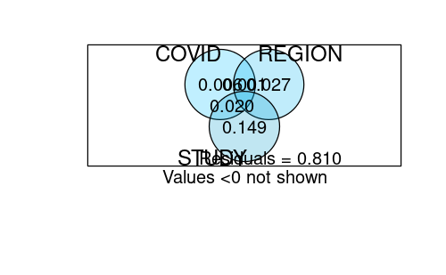

```r
plot (mainvarp, digits = 2, Xnames = c('COVID','REGION', 'STUDY'), bg=c("deepskyblue1", "deepskyblue2", "deepskyblue3"))
```

#Distance matrix

```r
dissector <- function(physeq, distm, var1, var2) {
  # Args:
  # - physeq: phyloseq object
  # - distm: a dist class object
  # - var1: a category within which to compare samples. For example, if var1= "Time", the distance between samples from the samples of the same time point will be measured.
  if (physeq@otu_table@taxa_are_rows=="FALSE"){
    dist.mat=vegdist((otu_table(physeq)), method="bray")
  } else{
    dist.mat=vegdist(t(otu_table(physeq)), method="bray")
  }
  A <- attr(dist.mat, "Size")
  B <- if (is.null(attr(dist.mat, "Labels"))) sequence(A) else attr(dist.mat, "Labels")
  if (isTRUE(attr(dist.mat, "Diag"))) attr(dist.mat, "Diag") <- FALSE
  if (isTRUE(attr(dist.mat, "Upper"))) attr(dist.mat, "Upper") <- FALSE
  d=data.frame(
    var1.names = B[unlist(lapply(sequence(A)[-1], function(x) x:A))],
    var2.names = rep(B[-length(B)], (length(B)-1):1),
    value = as.vector(dist.mat))
  v.1=as.data.frame(sample_data(physeq)[[var1]], row.names(sample_data(physeq)))
  colnames(v.1)=var1
  v.2=as.data.frame(sample_data(physeq)[[var2]], row.names(sample_data(physeq)))
  d[,var1]=v.1[,var1][match(d$var1.names, row.names(v.1))]
  if (var1==var2){
    colnames(v.2)=paste(var2,".")
    d[,paste(var2,".")]=v.2[,paste(var2,".")][match(d$var2.names, row.names(v.2))]
  } else{
    colnames(v.2)=var2
    d[,var2]=v.2[,var2][match(d$var2.names, row.names(v.2))]
  }
  d$Total="total"
  return(d)
}

d=dissector(rarefied, "bray", "COVID", "COVID")
d$Study.Accession=rarefied@sam_data$Study.Accession[match(d$var1.names,row.names(rarefied@sam_data))]
d$Study.Accession.=rarefied@sam_data$Study.Accession[match(d$var2.names,row.names(rarefied@sam_data))]
d$Region=rarefied@sam_data$Region[match(d$var1.names,row.names(rarefied@sam_data))]
d$Region.=rarefied@sam_data$Region[match(d$var2.names,row.names(rarefied@sam_data))]

write.table(d, "dissected.txt")
d=read.table("dissected.txt")
```

```r
#subset to within study replicates
e=d[which(d$Study.Accession==d$Study.Accession. &
            d$Region==d$Region. &
            d$COVID==d$`COVID .`&
            d$COVID!= "Recovered"),]
```

#Are there general effects of covid on microbiome richness?

```r
#Hill q0--Richness
rarefied@sam_data$Richness=specnumber(rarefied@otu_table)
#Hill q1--Effective Shannon
rarefied@sam_data$Shannon=hillR::hill_taxa(rarefied@otu_table@.Data, q=1)
#Hill q2-- Inverse Simpson
rarefied@sam_data$Simpson=hillR::hill_taxa(rarefied@otu_table@.Data, q=2)

alphas=as.data.frame(rarefied@sam_data[which(rarefied@sam_data$COVID!=0&rarefied@sam_data$COVID!="Recovered"),])

write.table(alphas, "alphas.txt")

fit.brm.richness=brm(bf(Richness~COVID+(1|Study.Accession/Region)), data = alphas,family = student(),cores = parallel::detectCores()-1)

saveRDS(fit.brm.richness, "fit.brm.richness.RDS")

richness.est=fitted(fit.brm.richness, re_formula = NA) %>%
  as_tibble() %>%
  bind_cols(fit.brm.richness$data %>%
              as_tibble())%>%
  distinct(COVID, Estimate, Q2.5, Q97.5)

fit.brm.richness$fit

Rich.plot <- ggplot() +
  # the data
  geom_jitter(data = fit.brm.richness$data,
             aes(x =COVID, y = Richness, group = Study.Accession,color=Study.Accession),
             size = 1) +
  # expected values for each environment from the model
  geom_point(data = richness.est,
             aes(x = COVID, y = Estimate),
             size = 2, color='darkblue') +
  geom_linerange(data =richness.est,
                 aes(x = COVID, ymin = Q2.5, ymax = Q97.5), color="darkblue")+
    theme_classic() +
  theme(axis.title = element_text(size = 10))+
 theme(axis.title.x=element_blank())+
   theme(legend.position = "none")+
  scale_color_brewer(palette="Set3")
Rich.plot


(hypothesis(fit.brm.richness, "Intercept+COVIDYes>Intercept"))
```

[output not shown]

#Is there an effect of region on the effect of covid on microbiome richness?

Remy: need help here with this kind of model. By region I mean gut or respiratory

```r
fit.brm.richness2=brm(bf(Richness~COVID*Region+(1|Study.Accession)), data = alphas,family = student(),cores = parallel::detectCores()-1)

saveRDS(fit.brm.richness2, "fit.brm.richness2.RDS")

richness.est2=fitted(fit.brm.richness2, re_formula = NA) %>%
  as_tibble() %>%
  bind_cols(fit.brm.richness2$data %>%
              as_tibble())%>%
  distinct(COVID,Region, Estimate, Q2.5, Q97.5)

fit.brm.richness2$fit

Rich.plot2 <- ggplot() +
  # the data
  geom_jitter(data = fit.brm.richness2$data,
             aes(x =COVID, y = Richness, group = Study.Accession,color=Study.Accession),
             size = 1) +
  # expected values for each environment from the model
  geom_point(data = richness.est2,
             aes(x = COVID, y = Estimate),
             size = 2, color='darkblue') +
  geom_linerange(data =richness.est2,
                 aes(x = COVID, ymin = Q2.5, ymax = Q97.5), color="darkblue")+
    theme_classic() +
  theme(axis.title = element_text(size = 10))+
 theme(axis.title.x=element_blank())+
   theme(legend.position = "none")
        scale_color_brewer(palette="Set3")
Rich.plot2


(hypothesis(fit.brm.richness2, "(Intercept+COVIDYes)/Intercept<(Intercept+COVIDYes:RegionOralDURT)+Intercept/(RegionOralDURT+Intercept)"))
```

[output not shown]

#Are there general effects of covid on microbiome diversity–simpson?

```r
fit.brm.simpson=brm(bf(Simpson~COVID+(1|Study.Accession/Region)), data = alphas,family = lognormal(),cores = parallel::detectCores()-1)

saveRDS(fit.brm.simpson, "fit.brm.simpson.RDS")

simpson.est=fitted(fit.brm.simpson, re_formula = NA) %>%
  as_tibble() %>%
  bind_cols(fit.brm.simpson$data %>%
              as_tibble())%>%
  distinct(COVID, Estimate, Q2.5, Q97.5)

fit.brm.simpson$fit

Simpson.plot <- ggplot() +
  # the data
  geom_jitter(data = fit.brm.simpson$data,
             aes(x =COVID, y = Simpson, group = Study.Accession,color=Study.Accession),
             size = 1) +
  # expected values for each environment from the model
  geom_point(data = simpson.est,
             aes(x = COVID, y = Estimate),
             size = 2, color='darkblue') +
  geom_linerange(data =simpson.est,
                 aes(x = COVID, ymin = Q2.5, ymax = Q97.5), color="darkblue")+
    theme_classic() +
  theme(axis.title = element_text(size = 10))+
 theme(axis.title.x=element_blank())+
   theme(legend.position = "none")+
  scale_color_brewer(palette="Set3")
Simpson.plot

(hypothesis(fit.brm.simpson, "Intercept+COVIDYes>Intercept"))
```

[output not shown]

```r
fit.brm.simpson2=brm(bf(Simpson~COVID*Region+(1|Study.Accession)), data = alphas,family = lognormal(),cores = parallel::detectCores()-1)

saveRDS(fit.brm.simpson2, "fit.brm.simpson2.RDS")

simpson2.est=fitted(fit.brm.simpson2, re_formula = NA) %>%
  as_tibble() %>%
  bind_cols(fit.brm.simpson2$data %>%
              as_tibble())%>%
  distinct(COVID, Estimate, Q2.5, Q97.5)

fit.brm.simpson2$fit

Simpson2.plot <- ggplot() +
  # the data
  geom_jitter(data = fit.brm.simpson2$data,
             aes(x =COVID, y = Simpson, group = Study.Accession,color=Study.Accession),
             size = 1) +
  # expected values for each environment from the model
  geom_point(data = simpson2.est,
             aes(x = COVID, y = Estimate),
             size = 2, color='darkblue') +
  geom_linerange(data =simpson2.est,
                 aes(x = COVID, ymin = Q2.5, ymax = Q97.5), color="darkblue")+
    theme_classic() +
  theme(axis.title = element_text(size = 10))+
 theme(axis.title.x=element_blank())+
   theme(legend.position = "none")+
  scale_color_brewer(palette="Set3")
Simpson2.plot

(hypothesis(fit.brm.simpson2, "(Intercept+COVIDYes)/Intercept<(Intercept+COVIDYes:RegionOralDURT)+Intercept/(RegionOralDURT+Intercept)"))
```

[output not shown]

#metadata table

```r
a=as.data.frame((rarefied@sam_data)) %>%
group_by(Study.Accession)%>%
summarize(samples=n(),
Original.Reads=mean(Original.Reads),
Filtered.reads=mean(Filtered.Reads),
Final.reads=mean(pseq),
Article=first(Article),
Authors=first(Authors),
DOI=first(DOI),
Region=unique(Sample),
Method=first(Method),
Extraction.Kit=first(Kit),
Primers=first(Primers),
Country=first(Country),
Mean.richness=mean(Richness))
```

#split by region

```r
Oral=subset_samples(rarefied, rarefied@sam_data$Region!="Gut")

Oral.g=tax_glom(Oral, "Genus")
taxa_names(Oral.g)=paste0((Oral.g@tax_table)[,6],1:ntaxa(Oral.g))

Gut=subset_samples(rarefied, rarefied@sam_data$Region=="Gut")
Gut.g=tax_glom(Gut, "Genus")
taxa_names(Gut.g)=paste0((Gut.g@tax_table)[,6],1:ntaxa(Gut.g))
```

#Differential abundance with Maaslin2

```r
rarefied.=rarefied
rarefied.=subset_taxa(rarefied., Genus="Chloroplast")
taxa_names(rarefied.)=paste0("ASV", 1:ntaxa(rarefied.))
rarefied.=tax_glom(rarefied., "Genus")
rarefied.=prune_samples(rarefied.@sam_data$COVID!="Recovered", rarefied.)

Oral=subset_samples(rarefied., rarefied.@sam_data$Region!="Gut")

Gut=subset_samples(rarefied., rarefied.@sam_data$Region=="Gut")

fit_data_Gut = Maaslin2(input_data = as.matrix(as.data.frame(otu_table(Gut))),
                             input_metadata = data.frame(Gut@sam_data),
                             output = "Maaslin.Covid.Gut",
                             fixed_effects = c("COVID"),
                             random_effects = c("Study.Accession","Sample"),
                             min_prevalence = 0.2)
```

[output not shown]

[output not shown]

[output not shown]

[output not shown]

[output not shown]

[output not shown]

[output not shown]

[output not shown]

[output not shown]

[output not shown]

[output not shown]

[output not shown]

[output not shown]

[output not shown]

[output not shown]

[output not shown]

[output not shown]

[output not shown]

[output not shown]

[output not shown]

[output not shown]

[output not shown]

[output not shown]

[output not shown]

[output not shown]

[output not shown]

[output not shown]

[output not shown]

[output not shown]

[output not shown]

[output not shown]

[output not shown]

[output not shown]

[output not shown]

[output not shown]

[output not shown]

[output not shown]

[output not shown]

[output not shown]

[output not shown]

[output not shown]

[output not shown]

[output not shown]

[output not shown]

[output not shown]

[output not shown]

[output not shown]

[output not shown]

[output not shown]

[output not shown]

[output not shown]

[output not shown]

[output not shown]

[output not shown]

[output not shown]

[output not shown]

[output not shown]

[output not shown]

[output not shown]

[output not shown]

[output not shown]

[output not shown]

[output not shown]

[output not shown]

[output not shown]

[output not shown]

[output not shown]

[output not shown]

[output not shown]

[output not shown]

[output not shown]

[output not shown]

[output not shown]

[output not shown]

[output not shown]

[output not shown]

[output not shown]

[output not shown]

[output not shown]

[output not shown]

[output not shown]

[output not shown]

[output not shown]

[output not shown]

[output not shown]

[output not shown]

[output not shown]

[output not shown]

[output not shown]

[output not shown]

[output not shown]

[output not shown]

[output not shown]

[output not shown]

[output not shown]

[output not shown]

[output not shown]

[output not shown]

[output not shown]

[output not shown]

[output not shown]

[output not shown]

[output not shown]

[output not shown]

[output not shown]

[output not shown]

[output not shown]

[output not shown]

[output not shown]

[output not shown]

[output not shown]

[output not shown]

[output not shown]

[output not shown]

[output not shown]

[output not shown]

[output not shown]

[output not shown]

[output not shown]

[output cut: 22 more lines]

[output not shown]

```r
fit_data_Oral = Maaslin2(input_data = as.matrix(as.data.frame(otu_table(Oral))),
                             input_metadata = data.frame(Oral@sam_data),
                             output = "Maaslin.Covid.Oral",
                             fixed_effects = c("COVID"),
                             random_effects = "Study.Accession",
                             min_prevalence = 0.2)
```

[output not shown]

[output cut: 107 more lines]

[output not shown]

#Process Maaslin2 results

```r
require(pheatmap)

tax=as.data.frame(as.matrix(rarefied.@tax_table))
Gutsig=read.table("Maaslin.Covid.Gut/significant_results.tsv", header=TRUE)
Gutsig=Gutsig[which(Gutsig$pval<0.01),]
Gutsig$Phylum=tax$Phylum[match(Gutsig$feature, row.names(tax))]
Gutsig$Class=tax$Class[match(Gutsig$feature, row.names(tax))]
Gutsig$Order=tax$Order[match(Gutsig$feature, row.names(tax))]
Gutsig$Family=tax$Family[match(Gutsig$feature, row.names(tax))]
Gutsig$Genus=tax$Genus[match(Gutsig$feature, row.names(tax))]

Gut.=subset_taxa(Gut, taxa_names(Gut) %in% Gutsig$feature)

df.gut=as.matrix(t(Gut.@otu_table@.Data))
colnames(df.gut)=Gut.@sam_data$COVID
df.gut=df.gut/2000
df.gut=df.gut[ , order(colnames(df.gut))]

quantile_breaks <- function(xs, n = 10) {
    breaks <- quantile(xs, probs = seq(0, 1, length.out = n))
    breaks[!duplicated(breaks)]
}

mat_breaks <- quantile_breaks(df.gut, n = 11)

pheatmap((df.gut),
         cluster_cols = FALSE,
         annotation_row = as.data.frame(Gut.@tax_table[,2]),
         labels_row = (Gut.@tax_table[,6]),
         color=viridis(length(mat_breaks) - 1),
         breaks=mat_breaks,
         gaps_col = sum(colnames(df.gut)=="No"))

Oralsig=read.table("Maaslin.Covid.Oral/significant_results.tsv", header=TRUE)
Oralsig=Oralsig[which(Oralsig$pval<0.01),]
Oralsig$Phylum=tax$Phylum[match(Oralsig$feature, row.names(tax))]
Oralsig$Class=tax$Class[match(Oralsig$feature, row.names(tax))]
Oralsig$Order=tax$Order[match(Oralsig$feature, row.names(tax))]
Oralsig$Family=tax$Family[match(Oralsig$feature, row.names(tax))]
Oralsig$Genus=tax$Genus[match(Oralsig$feature, row.names(tax))]

Oral.=subset_taxa(Oral, taxa_names(Oral) %in% Oralsig$feature)
ggplot(Oralsig, aes(x=reorder(Genus,coef), y=coef, fill=Phylum))+
  geom_bar(stat="identity")+
  scale_color_viridis(discrete = TRUE)+theme_minimal()+
  theme(axis.text.x = element_text(angle = 90, vjust = 0.5, hjust=1))
```

[output not shown]